## **Reproducible Research**

**Hsin Yu Cheng**  
**June 14, 2015**

> Peer Assessment 1.  
> Dataset : https://d396qusza40orc.cloudfront.net/repdata%2Fdata%2Factivity.zip

## Download dataset from Internet

```r
setInternet2(TRUE)
temp <- tempfile()
download.file("https://d396qusza40orc.cloudfront.net/repdata%2Fdata%2Factivity.zip",temp)
data <- read.csv(unz(temp, "activity.csv"))
unlink(temp)
```

## Load Packages

```r
library(ggplot2)
library(scales)
library(dplyr)
library(tidyr)
```

## Loading and preprocessing the data

```r
NewDate <- data %>%
  mutate(steps = as.integer(steps),
         interval = as.character(interval),
         Date = as.Date(date, format("%Y-%m-%d")),
         Month = substring(Date,6,7),
         Day = substring(Date,9,10))
```

## What is mean total number of steps taken per day?

> Ignore the missing values in the dataset.  
> 1.Calculate the total number of steps taken per day.  
> 2.Make a histogram of the total number of steps taken each day.

```r
step <- NewDate %>%
  filter(!is.na(steps)) %>%
  group_by(Date) %>%
  summarise(Sum_steps = sum(steps))

step
```

```
## Source: local data frame [53 x 2]
##
##          Date Sum_steps
## 1  2012-10-02       126
## 2  2012-10-03     11352
## 3  2012-10-04     12116
## 4  2012-10-05     13294
## 5  2012-10-06     15420
## 6  2012-10-07     11015
## 7  2012-10-09     12811
## 8  2012-10-10      9900
## 9  2012-10-11     10304
## 10 2012-10-12     17382
## ..        ...       ...
```

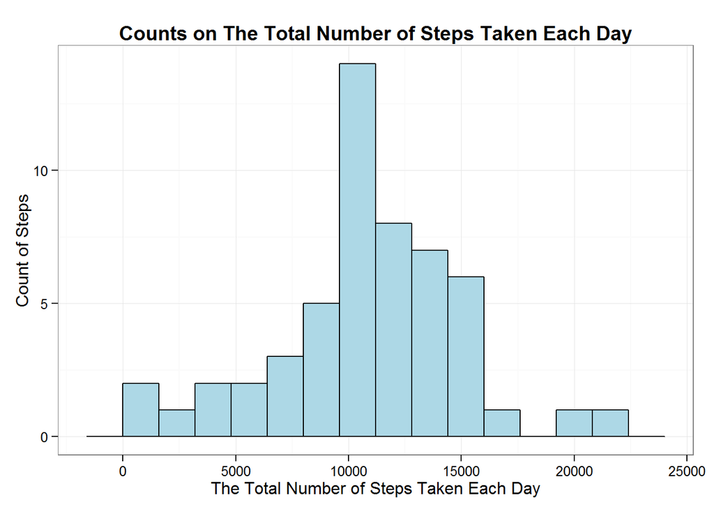

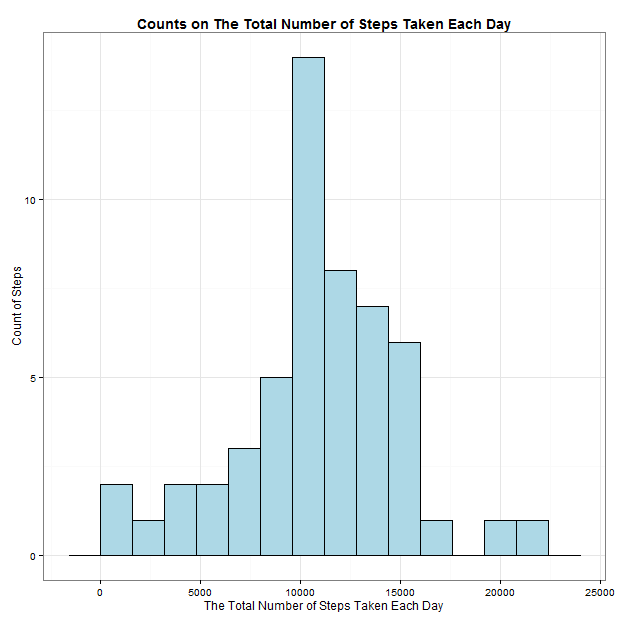

```r
ggplot(step, aes(x = Sum_steps)) +
  geom_histogram(fill = "lightblue", binwidth = 1600, color = "black") +
  theme_bw() +
  ylab("Count of Steps") +
  xlab("The Total Number of Steps Taken Each Day") +
  ggtitle("Counts on The Total Number of Steps Taken Each Day") +
  theme(plot.title = element_text(lineheight=.8, face="bold", size = 14))
```

> 3.Calculate and report the mean and median of the total number of steps taken per day.

```r
step %>%
  summarise(mean = mean(Sum_steps),
            median = median(Sum_steps))
```

```
## Source: local data frame [1 x 2]
##
##       mean median
## 1 10766.19  10765
```

- The **mean** of the total number of steps taken per day is 10766.19.
- The **median** of the total number of steps taken per day is 10765.

## What is the average daily activity pattern?

> 1.Make a time series plot (i.e. type = “l”) of the 5-minute interval (x-axis) and the average number of steps taken, averaged across all days (y-axis)

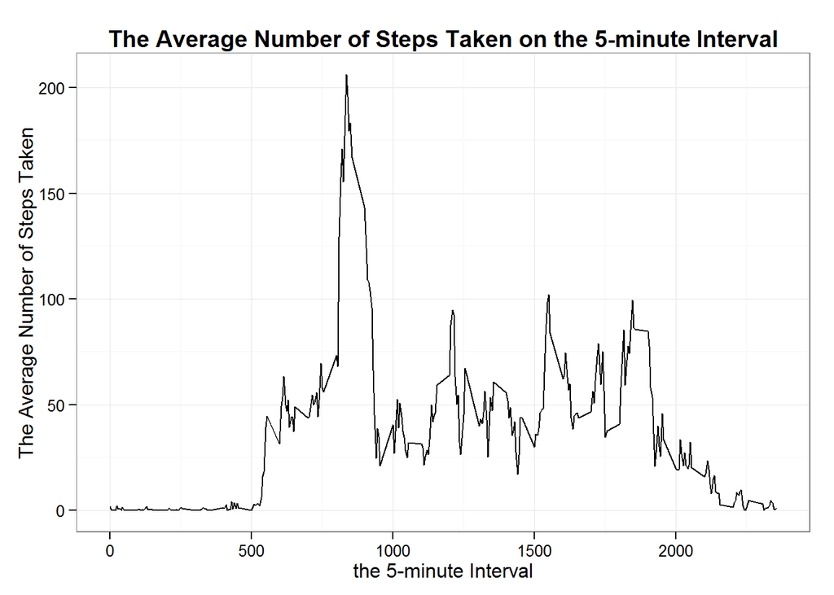

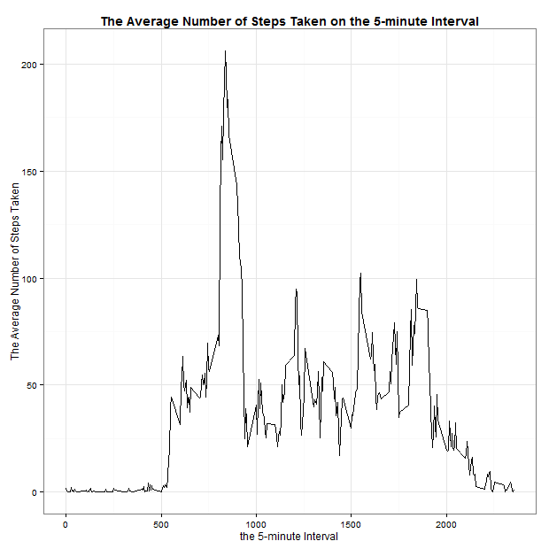

```r
intervals <- NewDate %>%
  filter(!is.na(steps)) %>%
  group_by(interval) %>%
  summarise(Mean_steps = mean(steps)) %>%
  mutate(interval = as.integer(interval))


ggplot(intervals, aes(x = interval , y = Mean_steps)) +
  geom_line() +
  theme_bw() +
  ylab("The Average Number of Steps Taken") +
  xlab("the 5-minute Interval") +
  ggtitle("The Average Number of Steps Taken on the 5-minute Interval") +
  theme(plot.title = element_text(lineheight=.8, face="bold", size = 14))
```

> 2.Which 5-minute interval, on average across all the days in the dataset, contains the maximum number of steps?

```r
intervals %>% mutate(rank = min_rank(desc(Mean_steps))) %>% filter(rank == 1)
```

```
## Source: local data frame [1 x 3]
##
##   interval Mean_steps rank
## 1      835   206.1698    1
```

**The interval 835** contains the maximum number of steps at 206.1698.

## Imputing missing values

> 1.Calculate and report the total number of missing values in the dataset.

```r
Missing <- NewDate %>%
  filter(is.na(steps)) %>%
  summarise(Missing_Value = length(steps))
Missing
```

```
##   Missing_Value
## 1          2304
```

The total number of missing values are **2304**.

> 2.Devise a strategy for filling in all of the missing values in the dataset.  
> 3.Create a new dataset that is equal to the original dataset but with the missing data filled in.

> **Strategy** :  
> Use the mean of total number steps corresponding to the 5 interval for filling in all of the missing values.

```r
only_Missing_Value <- NewDate %>% filter(is.na(steps))

for (i in 1:nrow(only_Missing_Value)) {
  only_Missing_Value$steps[i] <- intervals[which(only_Missing_Value$interval[i] == intervals$interval), ]$Mean_steps
    }

All_data <- rbind(only_Missing_Value, NewDate %>% filter(!is.na(steps)))

sum(is.na(All_data))
```

```
## [1] 0
```

In the new dataset, the number of missing values are 0.

> 4.Make a histogram of the total number of steps taken each day and Calculate and report the mean and median total number of steps taken per day.

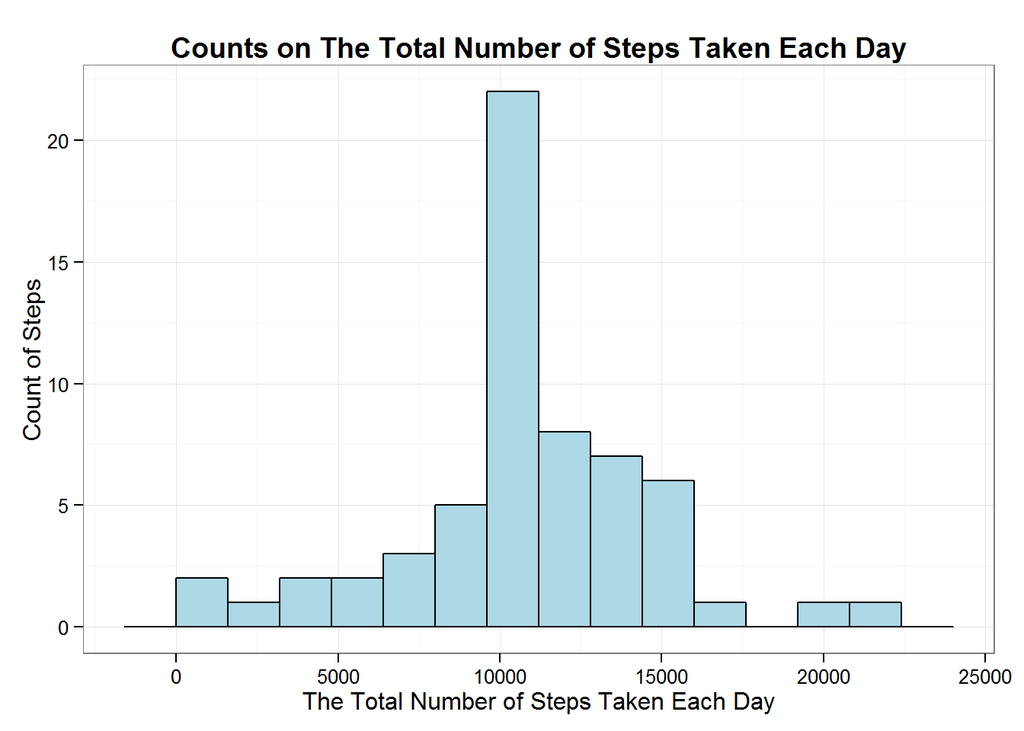

```r
No_NA <- All_data %>%
  group_by(Date) %>%
  summarise(Sum_steps = sum(steps))

ggplot(No_NA, aes(x = Sum_steps)) +
  geom_histogram(fill = "lightblue", binwidth = 1600, color = "black") +
  theme_bw() +
  ylab("Count of Steps") +
  xlab("The Total Number of Steps Taken Each Day") +
  ggtitle("Counts on The Total Number of Steps Taken Each Day") +
  theme(plot.title = element_text(lineheight=.8, face="bold", size = 14))
```

```r
No_NA %>%
  summarise(mean = mean(Sum_steps),
            median = median(Sum_steps))
```

```
## Source: local data frame [1 x 2]
##
##       mean   median
## 1 10766.19 10766.19
```

**Impact :**  
- The **mean** of the total number of steps taken per day is **10766.19**, which is **same** to that from the first part of the assignment.  
- The **median** of the total number of steps taken per day is **10766.19**, which is **different** to that from the first part of the assignment at **10765**.

[figure not shown]

## Are there differences in activity patterns between weekdays and weekends?

> 1.Create a new factor variable in the dataset with two levels - “weekday” and “weekend” indicating whether a given date is a weekday or weekend day.

```r
All_data$weekday <- as.POSIXlt(as.Date(All_data$Date))$wday

All_data <- All_data %>%
  mutate(Week = ifelse(weekday == 0 | weekday == 6, "weekend", "weekday"))

table(All_data$Week)
```

```
##
## weekday weekend
##   12960    4608
```

> 2.Make a panel plot containing a time series plot (i.e. type = “l”) of the 5-minute interval (x-axis) and the average number of steps taken, averaged across all weekday days or weekend days (y-axis).

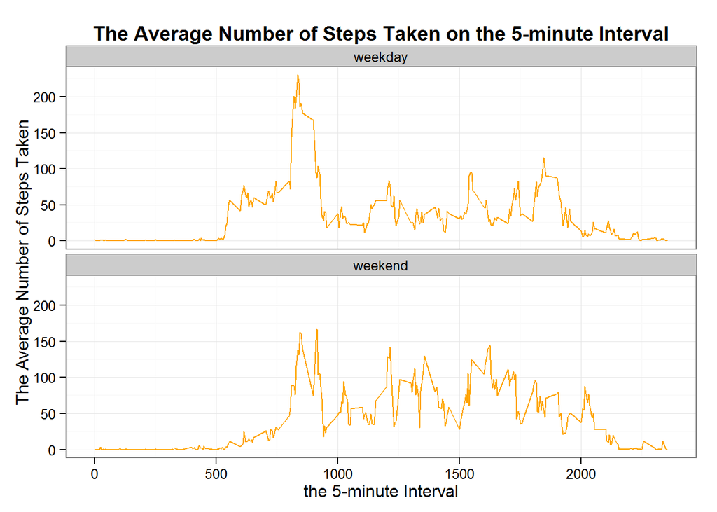

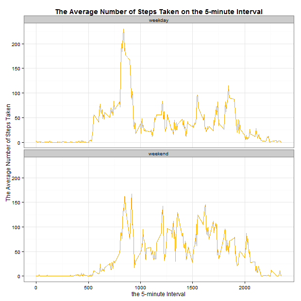

```r
Q4 <- All_data %>%
  group_by(Week, interval) %>%
  summarise(mean_steps = mean(steps)) %>%
  mutate(interval = as.integer(interval))


ggplot(Q4, aes(x = interval , y = mean_steps)) +
  geom_line(color = "orange") +
  facet_wrap(~Week, nrow=2, ncol=1) +
  theme_bw() +
  ylab("The Average Number of Steps Taken") +
  xlab("the 5-minute Interval") +
  ggtitle("The Average Number of Steps Taken on the 5-minute Interval") +
  theme(plot.title = element_text(lineheight=.8, face="bold", size = 14))
```